# Exercícios Aprendizado Supervisionado parte 2

### **Autor:** Glauco Lauria Marques Filho

# Resumo

#### Este arquivo contém a resolução dos exercícios da Aula 5 do curso CEDS-808: Aprendizado de Máquina.

# Sumário

- Início
- Resumo
- Sumário
- Importação de Requisitos
1. Dataset Breast Cancer Winconsin
- 1.a.I SVM
- 1.a.II Perceptron
- 1.a.III Multi-layer Perceptron
- 1.b Pre-processamento dos Dados
- 1.b.I SVM Pre-processado
- 1.b.II Perceptron Pre-processado
- 1.b.III Multi-layer Perceptron Pre-processado
- 1.c Comparando Resultados
2. Algoritmo Perceptron

# Importação de Requisitos

```python
from ucimlrepo import fetch_ucirepo # Biblioteca que possui os dados da base Breast Cancer Winconsin
from sklearn.svm import SVC
from sklearn.model_selection import KFold
import numpy as np
import matplotlib.pyplot as plt
from sklearn.linear_model import Perceptron
from sklearn.preprocessing import LabelEncoder
from sklearn.neural_network import MLPClassifier
from sklearn.preprocessing import MinMaxScaler
import pandas as pd
```

# 1. Dataset Breast Cancer Winconsin

Utilizando o dataset Breast Cancer Winconsin para o exercício. Importando o dataset da biblioteca, e carregando dataframes de Features e Target.

```python
# Importando o dataset Breast Cancer Winconsin
breast_c = fetch_ucirepo(id=17)
# Definindo dataframe de Features e target
X = breast_c.data.features
y = breast_c.data.targets
```

Pritando um pouco dos dataframes para uma primeira exploração da base de dados.

```python
X.head()
```

|  | radius1 | texture1 | perimeter1 | area1 | smoothness1 | compactness1 | concavity1 | concave_points1 | symmetry1 | fractal_dimension1 | ... | radius3 | texture3 | perimeter3 | area3 | smoothness3 | compactness3 | concavity3 | concave_points3 | symmetry3 | fractal_dimension3 |
| --- | --- | --- | --- | --- | --- | --- | --- | --- | --- | --- | --- | --- | --- | --- | --- | --- | --- | --- | --- | --- | --- |
| 0 | 17.99 | 10.38 | 122.80 | 1001.0 | 0.11840 | 0.27760 | 0.3001 | 0.14710 | 0.2419 | 0.07871 | ... | 25.38 | 17.33 | 184.60 | 2019.0 | 0.1622 | 0.6656 | 0.7119 | 0.2654 | 0.4601 | 0.11890 |
| 1 | 20.57 | 17.77 | 132.90 | 1326.0 | 0.08474 | 0.07864 | 0.0869 | 0.07017 | 0.1812 | 0.05667 | ... | 24.99 | 23.41 | 158.80 | 1956.0 | 0.1238 | 0.1866 | 0.2416 | 0.1860 | 0.2750 | 0.08902 |
| 2 | 19.69 | 21.25 | 130.00 | 1203.0 | 0.10960 | 0.15990 | 0.1974 | 0.12790 | 0.2069 | 0.05999 | ... | 23.57 | 25.53 | 152.50 | 1709.0 | 0.1444 | 0.4245 | 0.4504 | 0.2430 | 0.3613 | 0.08758 |
| 3 | 11.42 | 20.38 | 77.58 | 386.1 | 0.14250 | 0.28390 | 0.2414 | 0.10520 | 0.2597 | 0.09744 | ... | 14.91 | 26.50 | 98.87 | 567.7 | 0.2098 | 0.8663 | 0.6869 | 0.2575 | 0.6638 | 0.17300 |
| 4 | 20.29 | 14.34 | 135.10 | 1297.0 | 0.10030 | 0.13280 | 0.1980 | 0.10430 | 0.1809 | 0.05883 | ... | 22.54 | 16.67 | 152.20 | 1575.0 | 0.1374 | 0.2050 | 0.4000 | 0.1625 | 0.2364 | 0.07678 |

5 rows × 30 columns

```python
y.tail()
```

|  | Diagnosis |
| --- | --- |
| 564 | M |
| 565 | M |
| 566 | M |
| 567 | M |
| 568 | B |

# 1.a.I SVM

Nesse item iremos aplicar o algoritmo de SVM visto em aula.

Faremos uma modelagem primeiro variando os kernels do SVM

```python
SVM_kernels = ["linear", "poly", "rbf", "sigmoid"]
SVM_mean_accuracy = []
for kernel in SVM_kernels:
    print(f"Kernel = {kernel}")
    svm_classifier = SVC(kernel=kernel)
    acuracias = []
    kf = KFold(n_splits=5)
    for train_index, test_index in kf.split(X):
        X_train , X_test = X.iloc[train_index], X.iloc[test_index]
        y_train , y_test = y.iloc[train_index], y.iloc[test_index]
        svm_classifier.fit(X_train,np.ravel(y_train))
        accuracy = svm_classifier.score(X_test, np.ravel(y_test))
        acuracias.append(accuracy)
    acuracia_media = np.mean(acuracias)
    SVM_mean_accuracy.append(acuracia_media)
    print(f"Mean Accuracy at 5 folds = {acuracia_media}\n")
```

```
Kernel = linear
Mean Accuracy at 5 folds = 0.9525384257102933

Kernel = poly
Mean Accuracy at 5 folds = 0.9069243906225741

Kernel = rbf
Mean Accuracy at 5 folds = 0.9069243906225741

Kernel = sigmoid
Mean Accuracy at 5 folds = 0.43758733115975784
```

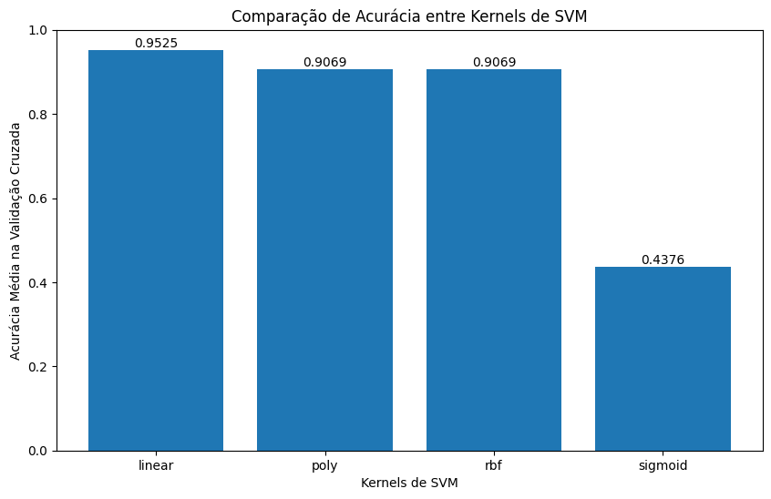

```python
plt.figure(figsize=(10, 6))
bars =plt.bar(SVM_kernels, SVM_mean_accuracy)
plt.xlabel('Kernels de SVM')
plt.ylabel('Acurácia Média na Validação Cruzada')
plt.title('Comparação de Acurácia entre Kernels de SVM')
plt.ylim(0, 1)
for bar in bars:
    yval = bar.get_height()
    plt.text(bar.get_x() + bar.get_width()/2, yval, round(yval, 4), va='bottom', ha='center')
plt.show()
```

Tivemos uma media de acuracia maior utilizando o Kernel Linear, chegando a 95% de acuracia.

Agora faremos uma variacao dos Kernels e tambem os Gammas e Cs.

```python
# SVM_kernels = ["linear", "poly", "rbf", "sigmoid"]
SVM_kernels = ["linear"]
gammas = [0.1,1,10]
C_values = [0.1,1,10]
SVM_Linear_mean_accuracy = []
SVM_Linear_models = []
for kernel in SVM_kernels:
    for gamma in gammas:
        for C in C_values:
            model = f"Kernel:{kernel}, Gamma:{gamma}, C:{C}"
            SVM_Linear_models.append(model)
            print(model)
            svm_classifier = SVC(kernel=kernel, gamma=gamma, C=C)
            acuracias = []
            kf = KFold(n_splits=5)
            for train_index, test_index in kf.split(X):
                X_train , X_test = X.iloc[train_index], X.iloc[test_index]
                y_train , y_test = y.iloc[train_index], y.iloc[test_index]
                svm_classifier.fit(X_train,np.ravel(y_train))
                accuracy = svm_classifier.score(X_test, np.ravel(y_test))
                acuracias.append(accuracy)
            acuracia_media = np.mean(acuracias)
            SVM_Linear_mean_accuracy.append(acuracia_media)
            print(f"Mean Accuracy at 5 folds = {acuracia_media}\n")
```

```
Kernel:linear, Gamma:0.1, C:0.1
Mean Accuracy at 5 folds = 0.9455053563111318

Kernel:linear, Gamma:0.1, C:1
Mean Accuracy at 5 folds = 0.9525384257102933

Kernel:linear, Gamma:0.1, C:10
Mean Accuracy at 5 folds = 0.9455208818506444

Kernel:linear, Gamma:1, C:0.1
Mean Accuracy at 5 folds = 0.9455053563111318

Kernel:linear, Gamma:1, C:1
Mean Accuracy at 5 folds = 0.9525384257102933

Kernel:linear, Gamma:1, C:10
Mean Accuracy at 5 folds = 0.9455208818506444

Kernel:linear, Gamma:10, C:0.1
Mean Accuracy at 5 folds = 0.9455053563111318

Kernel:linear, Gamma:10, C:1
Mean Accuracy at 5 folds = 0.9525384257102933

Kernel:linear, Gamma:10, C:10
Mean Accuracy at 5 folds = 0.9455208818506444
```

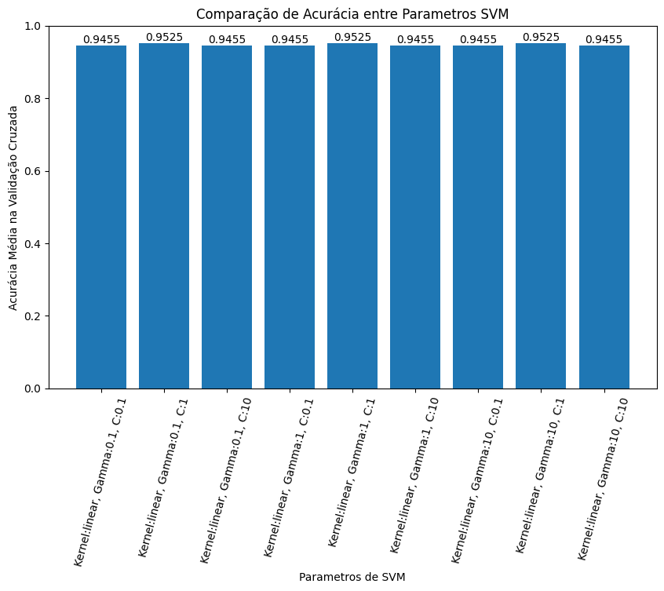

```python
plt.figure(figsize=(10, 6))
bars =plt.bar(SVM_Linear_models, SVM_Linear_mean_accuracy)
plt.xlabel('Parametros de SVM')
plt.ylabel('Acurácia Média na Validação Cruzada')
plt.title('Comparação de Acurácia entre Parametros SVM')
plt.ylim(0, 1)
plt.xticks(rotation=75)

for bar in bars:
    yval = bar.get_height()
    plt.text(bar.get_x() + bar.get_width()/2, yval, round(yval, 4), va='bottom', ha='center')
plt.show()
```

```python
# SVM_kernels = ["linear", "poly", "rbf", "sigmoid"]
SVM_kernels = ["rbf"]
gammas = [0.1,1,10]
C_values = [0.1,1,10]
SVM_Rbf_mean_accuracy = []
SVM_Rbf_models = []
for kernel in SVM_kernels:
    for gamma in gammas:
        for C in C_values:
            model = f"Kernel:{kernel}, Gamma:{gamma}, C:{C}"
            SVM_Rbf_models.append(model)
            print(model)
            svm_classifier = SVC(kernel=kernel, gamma=gamma, C=C)
            acuracias = []
            kf = KFold(n_splits=5)
            for train_index, test_index in kf.split(X):
                X_train , X_test = X.iloc[train_index], X.iloc[test_index]
                y_train , y_test = y.iloc[train_index], y.iloc[test_index]
                svm_classifier.fit(X_train,np.ravel(y_train))
                accuracy = svm_classifier.score(X_test, np.ravel(y_test))
                acuracias.append(accuracy)
            acuracia_media = np.mean(acuracias)
            SVM_Rbf_mean_accuracy.append(acuracia_media)
            print(f"Mean Accuracy at 5 folds = {acuracia_media}\n")
```

```
Kernel:rbf, Gamma:0.1, C:0.1
Mean Accuracy at 5 folds = 0.6276665114112715

Kernel:rbf, Gamma:0.1, C:1
Mean Accuracy at 5 folds = 0.6276665114112715

Kernel:rbf, Gamma:0.1, C:10
Mean Accuracy at 5 folds = 0.6276665114112715

Kernel:rbf, Gamma:1, C:0.1
Mean Accuracy at 5 folds = 0.6276665114112715

Kernel:rbf, Gamma:1, C:1
Mean Accuracy at 5 folds = 0.6276665114112715

Kernel:rbf, Gamma:1, C:10
Mean Accuracy at 5 folds = 0.6276665114112715

Kernel:rbf, Gamma:10, C:0.1
Mean Accuracy at 5 folds = 0.6276665114112715

Kernel:rbf, Gamma:10, C:1
Mean Accuracy at 5 folds = 0.6276665114112715

Kernel:rbf, Gamma:10, C:10
Mean Accuracy at 5 folds = 0.6276665114112715
```

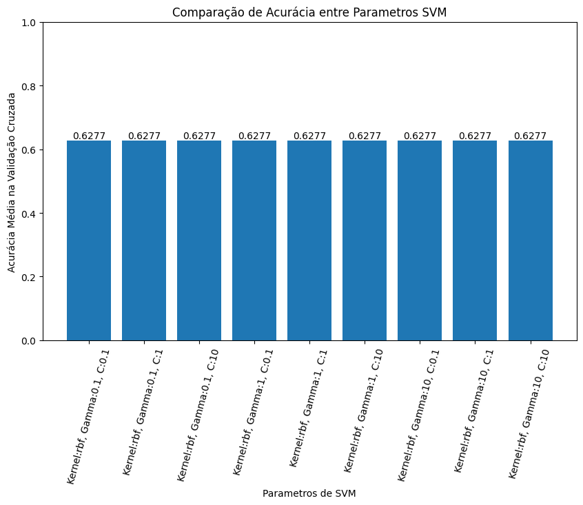

```python
plt.figure(figsize=(10, 6))
bars =plt.bar(SVM_Rbf_models, SVM_Rbf_mean_accuracy)
plt.xlabel('Parametros de SVM')
plt.ylabel('Acurácia Média na Validação Cruzada')
plt.title('Comparação de Acurácia entre Parametros SVM')
plt.ylim(0, 1)
plt.xticks(rotation=75)

for bar in bars:
    yval = bar.get_height()
    plt.text(bar.get_x() + bar.get_width()/2, yval, round(yval, 4), va='bottom', ha='center')
plt.show()
```

```python
# SVM_kernels = ["linear", "poly", "rbf", "sigmoid"]
SVM_kernels = ["sigmoid"]
gammas = [0.1,1,10]
C_values = [0.1,1,10]
SVM_Sigmoid_mean_accuracy = []
SVM_Sigmoid_models = []
for kernel in SVM_kernels:
    for gamma in gammas:
        for C in C_values:
            model = f"Kernel:{kernel}, Gamma:{gamma}, C:{C}"
            SVM_Sigmoid_models.append(model)
            print(model)
            svm_classifier = SVC(kernel=kernel, gamma=gamma, C=C)
            acuracias = []
            kf = KFold(n_splits=5)
            for train_index, test_index in kf.split(X):
                X_train , X_test = X.iloc[train_index], X.iloc[test_index]
                y_train , y_test = y.iloc[train_index], y.iloc[test_index]
                svm_classifier.fit(X_train,np.ravel(y_train))
                accuracy = svm_classifier.score(X_test, np.ravel(y_test))
                acuracias.append(accuracy)
            acuracia_media = np.mean(acuracias)
            SVM_Sigmoid_mean_accuracy.append(acuracia_media)
            print(f"Mean Accuracy at 5 folds = {acuracia_media}\n")
```

```
Kernel:sigmoid, Gamma:0.1, C:0.1
Mean Accuracy at 5 folds = 0.6276665114112715

Kernel:sigmoid, Gamma:0.1, C:1
Mean Accuracy at 5 folds = 0.6276665114112715

Kernel:sigmoid, Gamma:0.1, C:10
Mean Accuracy at 5 folds = 0.6276665114112715

Kernel:sigmoid, Gamma:1, C:0.1
Mean Accuracy at 5 folds = 0.6276665114112715

Kernel:sigmoid, Gamma:1, C:1
Mean Accuracy at 5 folds = 0.6276665114112715

Kernel:sigmoid, Gamma:1, C:10
Mean Accuracy at 5 folds = 0.6276665114112715

Kernel:sigmoid, Gamma:10, C:0.1
Mean Accuracy at 5 folds = 0.6276665114112715

Kernel:sigmoid, Gamma:10, C:1
Mean Accuracy at 5 folds = 0.6276665114112715

Kernel:sigmoid, Gamma:10, C:10
Mean Accuracy at 5 folds = 0.6276665114112715
```

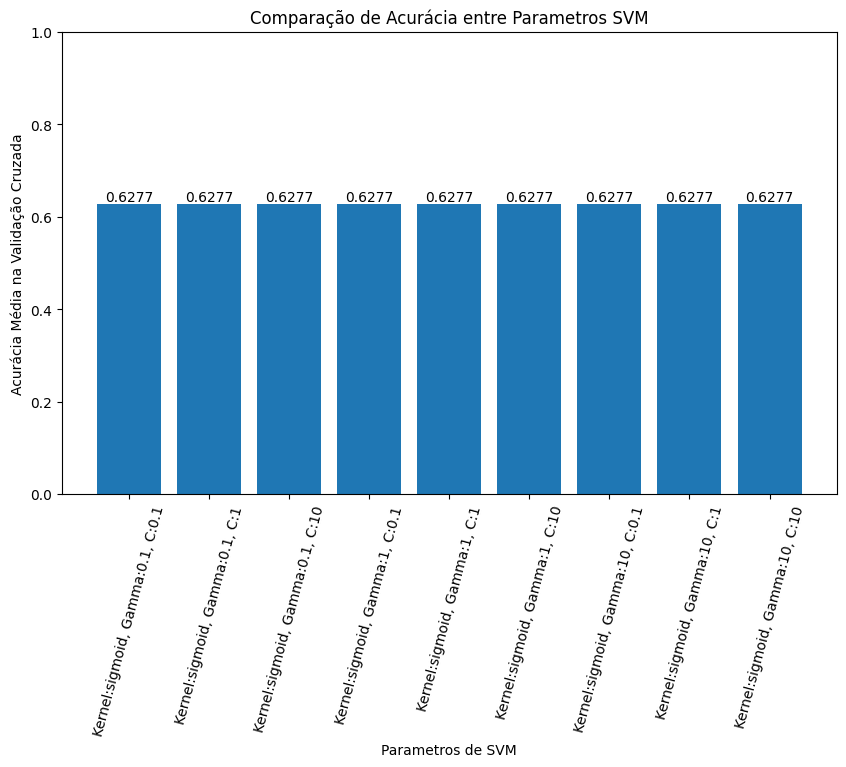

```python
plt.figure(figsize=(10, 6))
bars =plt.bar(SVM_Sigmoid_models, SVM_Sigmoid_mean_accuracy)
plt.xlabel('Parametros de SVM')
plt.ylabel('Acurácia Média na Validação Cruzada')
plt.title('Comparação de Acurácia entre Parametros SVM')
plt.ylim(0, 1)
plt.xticks(rotation=75)

for bar in bars:
    yval = bar.get_height()
    plt.text(bar.get_x() + bar.get_width()/2, yval, round(yval, 4), va='bottom', ha='center')
plt.show()
```

Para o modelo linear os parametros Gamma e C nao afetaram tanto a acuracia final. Para o sigmoid e Rbf nao influenciaram em nada. Porem para o Kernel Poly o hardware do aluno nao estava conseguindo processar com parametros gamma e C, na primeira simulacao o codigo ficou mais de 5 horas calculando e nao havia terminado ainda. Entao a analise do polinomio variando gamma e C ficara sem o teste polinomial para essa base de dados.

# 1.a.II Perceptron

Nesse item iremos aplicar o algoritmo de Perceptron visto em aula. Variando os parametros de penalidade.

```python
# Convertendo os rótulos para números (necessário para Perceptron no sklearn)
le = LabelEncoder()
y_num = le.fit_transform(y)
y_num = pd.DataFrame({"class":y_num})
y_num = y_num["class"]


# Inicializando a validação cruzada k-fold
kf = KFold(n_splits=5)

fold_number = 1
accuracies = []

perceptron_penalities_mean_accuracy = []

penalities = [None, "l2", "l1", "elasticnet"]
penalities_str = ["None", "l2", "l1", "elasticnet"]

for penality in penalities:
    if penality is not None:
        print(f"Penalidade: {penality}")
    else:
        print("Penalidade: None")
    # Iterando sobre os folds
    for train_index, test_index in kf.split(X):
        # Dividindo os dados em conjunto de treinamento e teste
        X_train, X_test = X.iloc[train_index], X.iloc[test_index]
        y_train, y_test = y_num.iloc[train_index], y_num.iloc[test_index]

        # Criando e treinando o modelo Perceptron
        perceptron = Perceptron(penalty=penality)
        perceptron.fit(X_train, np.ravel(y_train))

        # Fazendo previsões no conjunto de teste
        y_pred = perceptron.predict(X_test)

        # Calculando a acurácia do fold atual
        accuracy = np.mean(y_pred == np.ravel(y_test))
        accuracies.append(accuracy)

        # Imprimindo o resultado do fold atual
        print(f"Fold {fold_number}: Accuracy = {accuracy}")
        fold_number += 1
    fold_number = 1

    # Calculando a média das acurácias
    mean_accuracy = np.mean(accuracies)
    perceptron_penalities_mean_accuracy.append(mean_accuracy)
    print(f'Mean Accuracy of all Folds: {mean_accuracy}\n')
```

```
Penalidade: None
Fold 1: Accuracy = 0.8771929824561403
Fold 2: Accuracy = 0.8859649122807017
Fold 3: Accuracy = 0.8771929824561403
Fold 4: Accuracy = 0.9298245614035088
Fold 5: Accuracy = 0.911504424778761
Mean Accuracy of all Folds: 0.8963359726750506

Penalidade: l2
Fold 1: Accuracy = 0.8070175438596491
Fold 2: Accuracy = 0.8947368421052632
Fold 3: Accuracy = 0.9473684210526315
Fold 4: Accuracy = 0.7543859649122807
Fold 5: Accuracy = 0.7876106194690266
Mean Accuracy of all Folds: 0.8672799254774104

Penalidade: l1
Fold 1: Accuracy = 0.8771929824561403
Fold 2: Accuracy = 0.8859649122807017
Fold 3: Accuracy = 0.8771929824561403
Fold 4: Accuracy = 0.9298245614035088
Fold 5: Accuracy = 0.504424778761062
Mean Accuracy of all Folds: 0.8498266314754438

Penalidade: elasticnet
Fold 1: Accuracy = 0.7192982456140351
Fold 2: Accuracy = 0.9035087719298246
Fold 3: Accuracy = 0.8421052631578947
Fold 4: Accuracy = 0.7192982456140351
Fold 5: Accuracy = 0.8938053097345132
Mean Accuracy of all Folds: 0.841270765409098
```

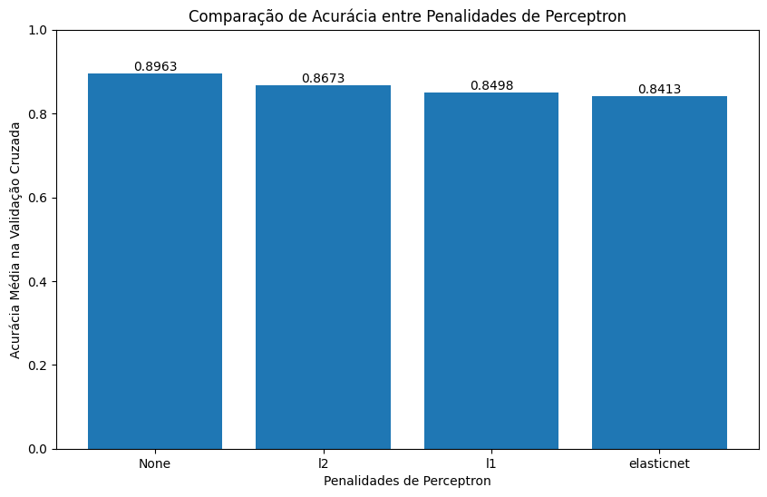

```python
plt.figure(figsize=(10, 6))
bars =plt.bar(penalities_str, perceptron_penalities_mean_accuracy)
plt.xlabel('Penalidades de Perceptron')
plt.ylabel('Acurácia Média na Validação Cruzada')
plt.title('Comparação de Acurácia entre Penalidades de Perceptron')
plt.ylim(0, 1)
for bar in bars:
    yval = bar.get_height()
    plt.text(bar.get_x() + bar.get_width()/2, yval, round(yval, 4), va='bottom', ha='center')
plt.show()
```

Foi variado os outros parametros possiveis no modelo, porem o unico que gerou alguma diferenca mesmo que pouco significativa foi a de penality. O modelo de Perceptron simples esta com uma acuracia inferior ao de SVM.

# 1.a.III Multi-layer Perceptron

Nesse item iremos aplicar o algoritmo de Multi-layer Perceptron visto em aula, alterando optimizadores e iteracoes.

```python
# Inicializando a validação cruzada k-fold
kf = KFold(n_splits=5)

fold_number = 1
accuracies = []


mlp_mean_accuracy = []

# Lista de otimizadores
optimizers = ['adam', 'sgd', 'lbfgs']

# Lista de iterações
iterations = [200, 500, 1000, 5000]

mlp_paramns = []


# Iterando sobre os otimizadores
for optimizer in optimizers:

    # Iterando sobre as iterações
    for iteration in iterations:
        modelo = f"Optimizer: {optimizer}, Iterations: {iteration}"
        print(modelo)
        mlp_paramns.append(modelo)

        # Iterando sobre os folds
        for train_index, test_index in kf.split(X):
            # Dividindo os dados em conjunto de treinamento e teste
            X_train, X_test = X.iloc[train_index], X.iloc[test_index]
            y_train, y_test = y.iloc[train_index], y_num.iloc[test_index]

            # Criando e treinando o modelo MLP com o otimizador atual e o número de iterações atual
            mlp = MLPClassifier(solver=optimizer, max_iter=iteration)
            mlp.fit(X_train, np.ravel(y_train))

            # Fazendo previsões no conjunto de teste
            y_pred = mlp.predict(X_test)

            # Calculando a acurácia do fold atual
            accuracy = np.mean(y_pred == y_test)
            accuracies.append(accuracy)

            # Imprimindo o resultado do fold atual
            print(f"  Fold {fold_number}: Accuracy = {accuracy}")
            mlp_mean_accuracy.append(accuracy)
            fold_number += 1
        fold_number = 1
        print()

# Calculandofold_numbery = np.mean(accuracies)
print(f'\nMean Accuracy of all Folds, Optimizers, and Iterations: {mean_accuracy}\n')
```

```
Optimizer: adam, Iterations: 200
```

```
  Fold 1: Accuracy = 0.0
  Fold 2: Accuracy = 0.0
```

```
  Fold 3: Accuracy = 0.0
  Fold 4: Accuracy = 0.0
  Fold 5: Accuracy = 0.0

Optimizer: adam, Iterations: 500
  Fold 1: Accuracy = 0.0
  Fold 2: Accuracy = 0.0
  Fold 3: Accuracy = 0.0
  Fold 4: Accuracy = 0.0
  Fold 5: Accuracy = 0.0

Optimizer: adam, Iterations: 1000
  Fold 1: Accuracy = 0.0
  Fold 2: Accuracy = 0.0
  Fold 3: Accuracy = 0.0
  Fold 4: Accuracy = 0.0
  Fold 5: Accuracy = 0.0

Optimizer: adam, Iterations: 5000
  Fold 1: Accuracy = 0.0
  Fold 2: Accuracy = 0.0
  Fold 3: Accuracy = 0.0
  Fold 4: Accuracy = 0.0
  Fold 5: Accuracy = 0.0

Optimizer: sgd, Iterations: 200
  Fold 1: Accuracy = 0.0
  Fold 2: Accuracy = 0.0
  Fold 3: Accuracy = 0.0
  Fold 4: Accuracy = 0.0
  Fold 5: Accuracy = 0.0

Optimizer: sgd, Iterations: 500
  Fold 1: Accuracy = 0.0
  Fold 2: Accuracy = 0.0
  Fold 3: Accuracy = 0.0
  Fold 4: Accuracy = 0.0
  Fold 5: Accuracy = 0.0

Optimizer: sgd, Iterations: 1000
  Fold 1: Accuracy = 0.0
  Fold 2: Accuracy = 0.0
  Fold 3: Accuracy = 0.0
  Fold 4: Accuracy = 0.0
  Fold 5: Accuracy = 0.0

Optimizer: sgd, Iterations: 5000
  Fold 1: Accuracy = 0.0
  Fold 2: Accuracy = 0.0
  Fold 3: Accuracy = 0.0
  Fold 4: Accuracy = 0.0
  Fold 5: Accuracy = 0.0

Optimizer: lbfgs, Iterations: 200
  Fold 1: Accuracy = 0.0
```

```
  Fold 2: Accuracy = 0.0
  Fold 3: Accuracy = 0.0
  Fold 4: Accuracy = 0.0
```

```
  Fold 5: Accuracy = 0.0

Optimizer: lbfgs, Iterations: 500
  Fold 1: Accuracy = 0.0
```

```
  Fold 2: Accuracy = 0.0
  Fold 3: Accuracy = 0.0
```

```
  Fold 4: Accuracy = 0.0
  Fold 5: Accuracy = 0.0

Optimizer: lbfgs, Iterations: 1000
  Fold 1: Accuracy = 0.0
```

```
  Fold 2: Accuracy = 0.0
  Fold 3: Accuracy = 0.0
```

```
  Fold 4: Accuracy = 0.0
  Fold 5: Accuracy = 0.0

Optimizer: lbfgs, Iterations: 5000
  Fold 1: Accuracy = 0.0
  Fold 2: Accuracy = 0.0
  Fold 3: Accuracy = 0.0
  Fold 4: Accuracy = 0.0
  Fold 5: Accuracy = 0.0


Mean Accuracy of all Folds, Optimizers, and Iterations: 0.841270765409098
```

# 1.b Pre-processamento dos Dados

Faremos agora um pre-processamento dos dados para utilizar em futuras analises.

Inicialmente vamos verificar os dados ausentes.

```python
null_values = X.isnull().sum()
null_values
```

```
radius1               0
texture1              0
perimeter1            0
area1                 0
smoothness1           0
compactness1          0
concavity1            0
concave_points1       0
symmetry1             0
fractal_dimension1    0
radius2               0
texture2              0
perimeter2            0
area2                 0
smoothness2           0
compactness2          0
concavity2            0
concave_points2       0
symmetry2             0
fractal_dimension2    0
radius3               0
texture3              0
perimeter3            0
area3                 0
smoothness3           0
compactness3          0
concavity3            0
concave_points3       0
symmetry3             0
fractal_dimension3    0
dtype: int64
```

Nao possuimos itens ausentes, podemos prosseguir.

Passamos agora para uma normalizacao.

```python
scaler = MinMaxScaler()
X_no_out_norma = scaler.fit_transform(X)
X_no_out_norma = pd.DataFrame(X_no_out_norma)
```

Foi tentado utilizar o modelo IQR para remocao de outliers, porem a acuracia abaixou demais, sendo desconsiderado essa etapa de pre-processamento.

# 1.b.I SVM Pre-processado

Vamos rodar novamente os modelos porem com os dados que foram pre-processados.

```python
SVM_kernels = ["linear", "poly", "rbf", "sigmoid"]
PRE_SVM_mean_accuracy = []
for kernel in SVM_kernels:
    print(f"Kernel = {kernel}")
    svm_classifier = SVC(kernel=kernel)
    acuracias = []
    kf = KFold(n_splits=5)
    for train_index, test_index in kf.split(X_no_out_norma):
        X_train , X_test = X_no_out_norma.iloc[train_index], X_no_out_norma.iloc[test_index]
        y_train , y_test = y.iloc[train_index], y.iloc[test_index]
        svm_classifier.fit(X_train,np.ravel(y_train))
        accuracy = svm_classifier.score(X_test, np.ravel(y_test))
        acuracias.append(accuracy)
    acuracia_media = np.mean(acuracias)
    PRE_SVM_mean_accuracy.append(acuracia_media)
    print(f"Mean Accuracy at 5 folds = {acuracia_media}\n")
```

```
Kernel = linear
Mean Accuracy at 5 folds = 0.9771619313771154

Kernel = poly
Mean Accuracy at 5 folds = 0.971914299021891

Kernel = rbf
Mean Accuracy at 5 folds = 0.9824406148113647

Kernel = sigmoid
Mean Accuracy at 5 folds = 0.2778761061946903
```

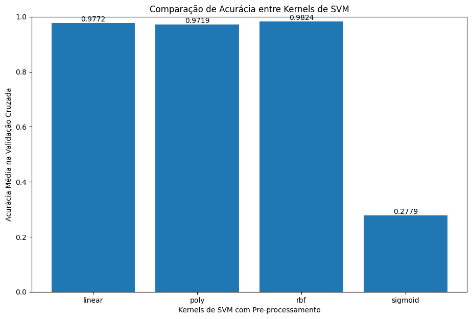

```python
plt.figure(figsize=(11, 7))
bars =plt.bar(SVM_kernels, PRE_SVM_mean_accuracy)
plt.xlabel('Kernels de SVM com Pre-processamento')
plt.ylabel('Acurácia Média na Validação Cruzada')
plt.title('Comparação de Acurácia entre Kernels de SVM')
plt.ylim(0, 1)
for bar in bars:
    yval = bar.get_height()
    plt.text(bar.get_x() + bar.get_width()/2, yval, round(yval, 4), va='bottom', ha='center')
plt.show()
```

O melhor caso antes do processamento era de 95%, agora chegamos a 98%, uma melhora de 3%, bem significativo!

# 1.b.II Perceptron Pre-processado

Vamos rodar novamente os modelos porem com os dados que foram pre-processados.

```python
# Convertendo os rótulos para números (necessário para Perceptron no sklearn)
le = LabelEncoder()
y_num = le.fit_transform(y)
y_num = pd.DataFrame({"class":y_num})
y_num = y_num["class"]


# Inicializando a validação cruzada k-fold
kf = KFold(n_splits=5)

fold_number = 1
accuracies = []

PRE_perceptron_penalities_mean_accuracy = []

penalities = [None, "l2", "l1", "elasticnet"]
penalities_str = ["None", "l2", "l1", "elasticnet"]

for penality in penalities:
    if penality is not None:
        print(f"Penalidade: {penality}")
    else:
        print("Penalidade: None")
    # Iterando sobre os folds
    for train_index, test_index in kf.split(X_no_out_norma):
        # Dividindo os dados em conjunto de treinamento e teste
        X_train, X_test = X_no_out_norma.iloc[train_index], X_no_out_norma.iloc[test_index]
        y_train, y_test = y_num.iloc[train_index], y_num.iloc[test_index]

        # Criando e treinando o modelo Perceptron
        perceptron = Perceptron(penalty=penality)
        perceptron.fit(X_train, np.ravel(y_train))

        # Fazendo previsões no conjunto de teste
        y_pred = perceptron.predict(X_test)

        # Calculando a acurácia do fold atual
        accuracy = np.mean(y_pred == np.ravel(y_test))
        accuracies.append(accuracy)

        # Imprimindo o resultado do fold atual
        print(f"Fold {fold_number}: Accuracy = {accuracy}")
        fold_number += 1
    fold_number = 1

    # Calculando a média das acurácias
    mean_accuracy = np.mean(accuracies)
    PRE_perceptron_penalities_mean_accuracy.append(mean_accuracy)
    print(f'Mean Accuracy of all Folds: {mean_accuracy}\n')
```

```
Penalidade: None
Fold 1: Accuracy = 0.956140350877193
Fold 2: Accuracy = 0.9210526315789473
Fold 3: Accuracy = 0.9736842105263158
Fold 4: Accuracy = 0.9824561403508771
Fold 5: Accuracy = 0.9646017699115044
Mean Accuracy of all Folds: 0.9595870206489675

Penalidade: l2
Fold 1: Accuracy = 0.956140350877193
Fold 2: Accuracy = 0.9385964912280702
Fold 3: Accuracy = 0.9736842105263158
Fold 4: Accuracy = 0.9736842105263158
Fold 5: Accuracy = 0.9646017699115044
Mean Accuracy of all Folds: 0.9604642136314236

Penalidade: l1
Fold 1: Accuracy = 0.9210526315789473
Fold 2: Accuracy = 0.9210526315789473
Fold 3: Accuracy = 0.9736842105263158
Fold 4: Accuracy = 1.0
Fold 5: Accuracy = 0.9911504424778761
Mean Accuracy of all Folds: 0.9607721368317548

Penalidade: elasticnet
Fold 1: Accuracy = 0.8771929824561403
Fold 2: Accuracy = 0.9385964912280702
Fold 3: Accuracy = 0.9736842105263158
Fold 4: Accuracy = 0.9649122807017544
Fold 5: Accuracy = 0.9646017699115044
Mean Accuracy of all Folds: 0.9565284893650052
```

O melhor caso antes do processamento era de 89%, agora chegamos a 96%, uma melhora de 7%, bem significativo!

# 1.b.III Multi-layer Perceptron Pre-processado

Vamos rodar novamente os modelos porem com os dados que foram pre-processados.

```python
# Inicializando a validação cruzada k-fold
kf = KFold(n_splits=5)

fold_number = 1
accuracies = []


PRE_mlp_mean_accuracy = []

# Lista de otimizadores
optimizers = ['adam', 'sgd', 'lbfgs']

# Lista de iterações
iterations = [200, 500, 1000, 5000]

mlp_paramns = []


# Iterando sobre os otimizadores
for optimizer in optimizers:

    # Iterando sobre as iterações
    for iteration in iterations:
        modelo = f"Optimizer: {optimizer}, Iterations: {iteration}"
        print(modelo)
        mlp_paramns.append(modelo)

        # Iterando sobre os folds
        for train_index, test_index in kf.split(X_no_out_norma):
            # Dividindo os dados em conjunto de treinamento e teste
            X_train, X_test = X_no_out_norma.iloc[train_index], X_no_out_norma.iloc[test_index]
            y_train, y_test = y.iloc[train_index], y_num.iloc[test_index]

            # Criando e treinando o modelo MLP com o otimizador atual e o número de iterações atual
            mlp = MLPClassifier(solver=optimizer, max_iter=iteration)
            mlp.fit(X_train, np.ravel(y_train))

            # Fazendo previsões no conjunto de teste
            y_pred = mlp.predict(X_test)

            # Calculando a acurácia do fold atual
            accuracy = np.mean(y_pred == y_test)
            accuracies.append(accuracy)

            # Imprimindo o resultado do fold atual
            print(f"  Fold {fold_number}: Accuracy = {accuracy}")
            PRE_mlp_mean_accuracy.append(accuracy)
            fold_number += 1
        fold_number = 1
        print()

# Calculandofold_numbery = np.mean(accuracies)
print(f'\nMean Accuracy of all Folds, Optimizers, and Iterations: {mean_accuracy}\n')
```

```
Optimizer: adam, Iterations: 200
```

```
  Fold 1: Accuracy = 0.0
```

```
  Fold 2: Accuracy = 0.0
```

```
  Fold 3: Accuracy = 0.0
```

```
  Fold 4: Accuracy = 0.0
```

```
  Fold 5: Accuracy = 0.0

Optimizer: adam, Iterations: 500
  Fold 1: Accuracy = 0.0
```

```
  Fold 2: Accuracy = 0.0
```

```
  Fold 3: Accuracy = 0.0
  Fold 4: Accuracy = 0.0
```

```
  Fold 5: Accuracy = 0.0

Optimizer: adam, Iterations: 1000
  Fold 1: Accuracy = 0.0
  Fold 2: Accuracy = 0.0
  Fold 3: Accuracy = 0.0
  Fold 4: Accuracy = 0.0
  Fold 5: Accuracy = 0.0

Optimizer: adam, Iterations: 5000
  Fold 1: Accuracy = 0.0
  Fold 2: Accuracy = 0.0
  Fold 3: Accuracy = 0.0
  Fold 4: Accuracy = 0.0
  Fold 5: Accuracy = 0.0

Optimizer: sgd, Iterations: 200
```

```
  Fold 1: Accuracy = 0.0
```

```
  Fold 2: Accuracy = 0.0
```

```
  Fold 3: Accuracy = 0.0
```

```
  Fold 4: Accuracy = 0.0
```

```
  Fold 5: Accuracy = 0.0

Optimizer: sgd, Iterations: 500
```

```
  Fold 1: Accuracy = 0.0
```

```
  Fold 2: Accuracy = 0.0
```

```
  Fold 3: Accuracy = 0.0
```

```
  Fold 4: Accuracy = 0.0
```

```
  Fold 5: Accuracy = 0.0

Optimizer: sgd, Iterations: 1000
  Fold 1: Accuracy = 0.0
  Fold 2: Accuracy = 0.0
  Fold 3: Accuracy = 0.0
  Fold 4: Accuracy = 0.0
  Fold 5: Accuracy = 0.0

Optimizer: sgd, Iterations: 5000
  Fold 1: Accuracy = 0.0
  Fold 2: Accuracy = 0.0
  Fold 3: Accuracy = 0.0
  Fold 4: Accuracy = 0.0
  Fold 5: Accuracy = 0.0

Optimizer: lbfgs, Iterations: 200
  Fold 1: Accuracy = 0.0
  Fold 2: Accuracy = 0.0
  Fold 3: Accuracy = 0.0
  Fold 4: Accuracy = 0.0
  Fold 5: Accuracy = 0.0

Optimizer: lbfgs, Iterations: 500
  Fold 1: Accuracy = 0.0
  Fold 2: Accuracy = 0.0
  Fold 3: Accuracy = 0.0
  Fold 4: Accuracy = 0.0
  Fold 5: Accuracy = 0.0

Optimizer: lbfgs, Iterations: 1000
  Fold 1: Accuracy = 0.0
  Fold 2: Accuracy = 0.0
  Fold 3: Accuracy = 0.0
  Fold 4: Accuracy = 0.0
  Fold 5: Accuracy = 0.0

Optimizer: lbfgs, Iterations: 5000
  Fold 1: Accuracy = 0.0
  Fold 2: Accuracy = 0.0
  Fold 3: Accuracy = 0.0
  Fold 4: Accuracy = 0.0
  Fold 5: Accuracy = 0.0


Mean Accuracy of all Folds, Optimizers, and Iterations: 0.9565284893650052
```

# 1.c. Comparando Resultados

```python
acuracias = [
    max(SVM_mean_accuracy),
    max(PRE_SVM_mean_accuracy),
    max(perceptron_penalities_mean_accuracy),
    max(PRE_perceptron_penalities_mean_accuracy),
    max(mlp_mean_accuracy),
    max(PRE_mlp_mean_accuracy),

]

legendas = [
    "SVM Raw",
    "SVM Pre-Proc.",
    "Perceptron Raw",
    "Perceptron Pre-Proc.",
    "MLP Raw",
    "MLP Pre-Proc.",
]
```

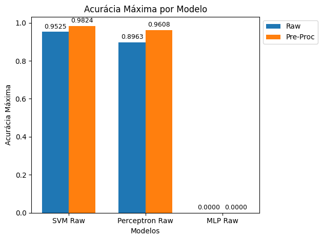

```python
raw_acuracias = acuracias[::2]
pre_proc_acuracias = acuracias[1::2]
posicoes = np.arange(len(legendas) // 2)
largura = 0.35
fig, ax = plt.subplots()
barras_raw = ax.bar(posicoes, raw_acuracias, largura, label='Raw')
barras_pre_proc = ax.bar(posicoes + largura, pre_proc_acuracias, largura, label='Pre-Proc')
for i, valor in enumerate(raw_acuracias):
    ax.text(i, valor + 0.01, f'{valor:.4f}', ha='center', va='bottom', fontsize=9)

for i, valor in enumerate(pre_proc_acuracias):
    ax.text(i + largura, valor + 0.01, f'{valor:.4f}', ha='center', va='bottom', fontsize=9)
ax.set_xlabel('Modelos')
ax.set_ylabel('Acurácia Máxima')
ax.set_title('Acurácia Máxima por Modelo')
ax.set_xticks(posicoes + largura / 2)
ax.set_xticklabels(legendas[::2])
ax.legend(loc='upper left', bbox_to_anchor=(1, 1))
plt.tight_layout()
plt.show()
```

Tivemos uma melhoria ate aque significativa ao fazer o pre-processamento.

# 2. Algoritmo Perceptron

Aplicaremos um algoritmo de Perceptron com os dados informados, utilizarei esse material como referencia:

https://medium.com/@urapython.community/perceptron-com-python-uma-introdu%C3%A7%C3%A3o-f19aaf9e9b64

```python
# Importacao das bibliotecas
from matplotlib.colors import ListedColormap
import matplotlib.pyplot as plt
import numpy as np
import pandas as pd
```

Criando a classe do Perceptron, usando conceitos básicos de Programação Orientada a Objetos (POO).

```python
class Perceptron:
    def __init__(self, eta=0.5, n_iter=10, limiar=-0.5):
        self.eta = eta
        self.n_iter = n_iter
        self.limiar = limiar

    def fit(self, X, y):
        self.w_ = np.zeros(1 + X.shape[1])
        # Definindo o erro do limiar em w0, como no slide
        self.w_[0] = - self.limiar
        self.errors_ = []

        for _ in range(self.n_iter):
            # erros da geracao
            errors = 0

            for xi, target in zip(X, y):

                # Inserindo o valor 1 para o w0
                xi = np.insert(xi, 0, 1)
                # Soma ponderada pelos pesos
                weighted_sum = np.dot(xi, self.w_)
                # Ativacao do perceptron
                output = self.ativacao(weighted_sum + self.limiar)
                # erro da previsao
                error = target - output
                # Atualizacao dos pesos
                self.w_ += self.eta * error * xi

                errors += int(error != 0.0)
            # Adicionando o erro da geracao
            self.errors_.append(errors)

    def ativacao(self, x):
        """Função de ativação que aplica o limiar."""
        return 1 if x >= 0 else 0  # Ajuste conforme a definição do limiar

    def predict(self, X):
        """Previsão da classe usando o vetor de pesos e o limiar."""
        X = np.hstack([np.ones((X.shape[0], 1)), X])
        weighted_sum = np.dot(X, self.w_)
        return np.where(weighted_sum >= 0, 1, 0)
```

Definicoes:

Febre, 1 para Sim, 0 para Nao.

Enjoo, 1 para Sim, 0 para Nao.

Manchas, 1 para Grandes, 0 para Pequenas.

Dores, 1 para Sim, 0 para nao.

Diagnostico, 1 para Doente, 0 para Saudavel.

```python
X = np.array([
    [1, 1, 0, 1],
    [0, 0, 1, 0],
    [1, 1, 0, 0],
    [1, 0, 1, 1],
    [1, 0, 0, 1],
    [0, 0, 1, 1]
])

y = np.array([1, 0, 0, 1, 0, 1])
```

```python
model = Perceptron()
model.fit(X, y)
print(f"Pesos do algorimo {model.w_}")
```

```
Pesos do algorimo [-1.  -1.   1.   1.   1.5]
```

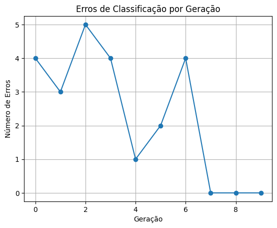

```python
# Plotando os erros por geração
plt.plot(model.errors_, marker='o')
plt.title('Erros de Classificação por Geração')
plt.xlabel('Geração')
plt.ylabel('Número de Erros')
plt.grid(True)
plt.show()
```

Podemos ver que ja na setima geracao o algoritmo nao errou mais suas classificacoes.

```python
luis = np.array([0, 0, 0, 1])
laura = np.array([1, 1, 1, 1])
prediction_luis = model.predict(np.array([luis]))
prediction_laura = model.predict(np.array([laura]))
print(f"Luis: {prediction_luis}")
print(f"Laura: {prediction_laura}")
```

```
Luis: [1]
Laura: [1]
```

O algoritmo preveu que Luis e Laura estavam doentes!